# examples_0603

A video-game developer is hoping to apply a vertical [shear](https://en.wikipedia.org/wiki/Shear_mapping) to a set of points by using matrix multiplication.

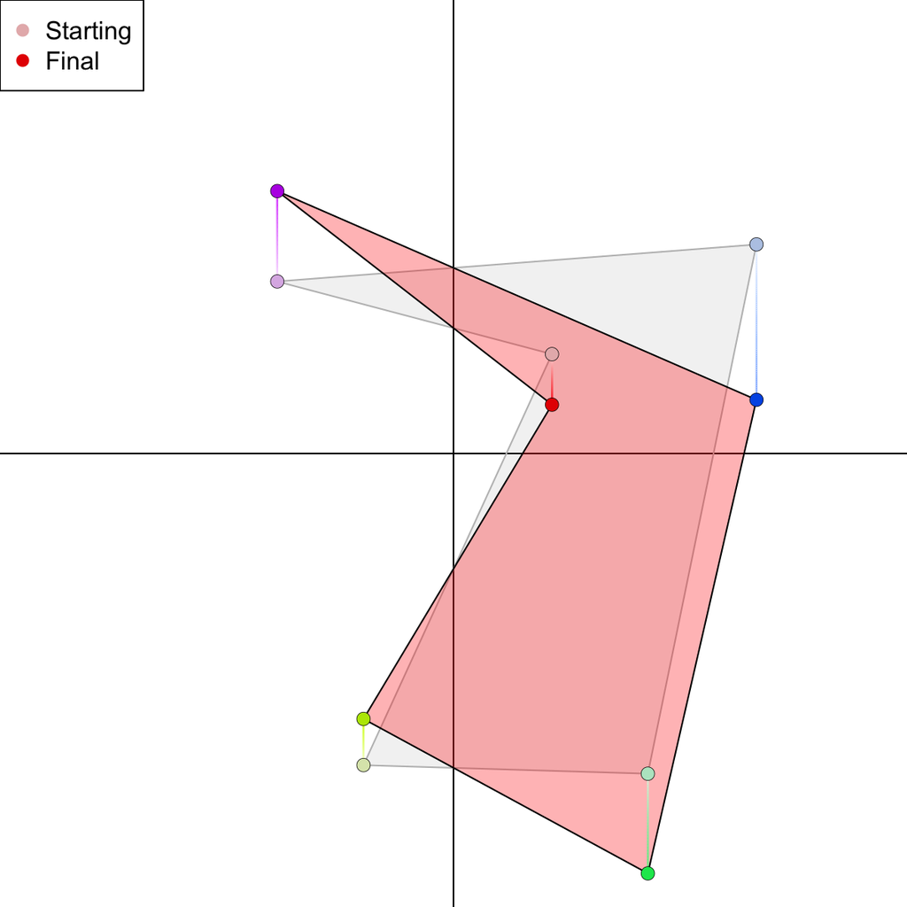

The starting points are stored as rows in a 5 $\times$ 2 matrix $S$.

$$S=\begin{bmatrix}
1.695 & 1.71\\
-1.549 & -5.363\\
3.345 & -5.511\\
5.215 & 3.599\\
-3.033 & 2.961
\end{bmatrix}$$

The vertical shear matrix can be found by using $k=-0.513$ in the formula matrix.

$$T~=~\begin{bmatrix}
1 & k\\
0 & 1
\end{bmatrix}$$

The final points (in matrix $F$) are found by multiplying $S\cdot T$.

$$F=S\cdot T$$

That multiplication can be done using the diagram below.

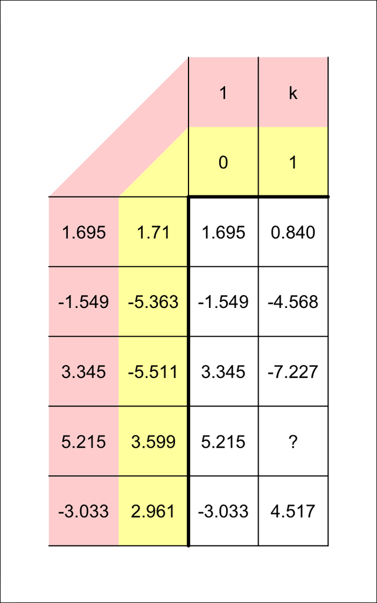

What is the new y coordinate when point $(5.215, 3.599)$ undergoes the vertical shear transformation with $k=-0.513$?

The vertical shear transformation matrix:

$$T=\begin{bmatrix}
1 & -0.513\\
0 & 1
\end{bmatrix}$$

We are looking for the new y coordinate after point $(5.215, 3.599)$ undergoes the shear transformation. Use column 2 of $T$:

$$(5.215)(-0.513)~+~(3.599)(1)$$

The new y coordinate is 0.923705.

A video-game developer is hoping to apply a vertical [shear](https://en.wikipedia.org/wiki/Shear_mapping) to a set of points by using matrix multiplication.

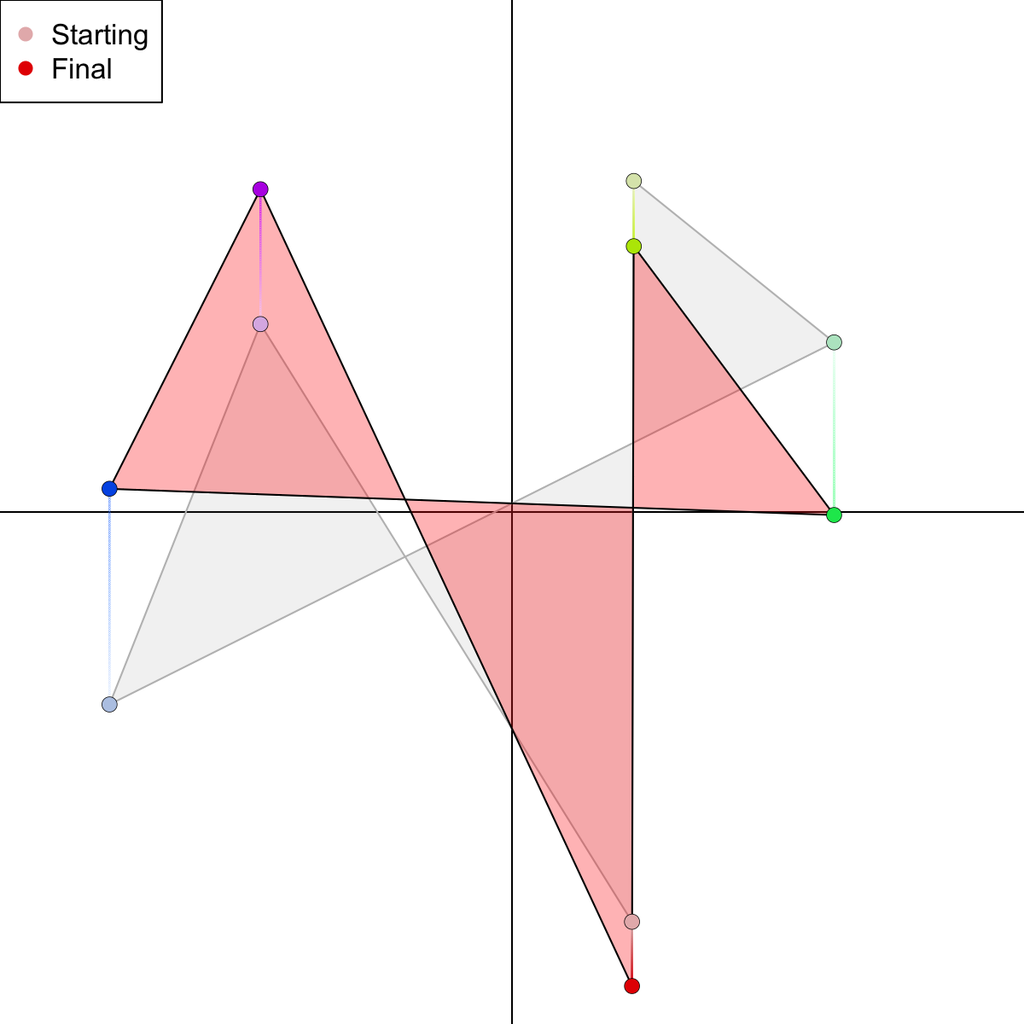

The starting points are stored as rows in a 5 $\times$ 2 matrix $S$.

$$S=\begin{bmatrix}
1.471 & -5.022\\
1.493 & 4.057\\
3.948 & 2.079\\
-4.933 & -2.359\\
-3.083 & 2.303
\end{bmatrix}$$

The vertical shear matrix can be found by using $k=-0.536$ in the formula matrix.

$$T~=~\begin{bmatrix}
1 & k\\
0 & 1
\end{bmatrix}$$

The final points (in matrix $F$) are found by multiplying $S\cdot T$.

$$F=S\cdot T$$

That multiplication can be done using the diagram below.

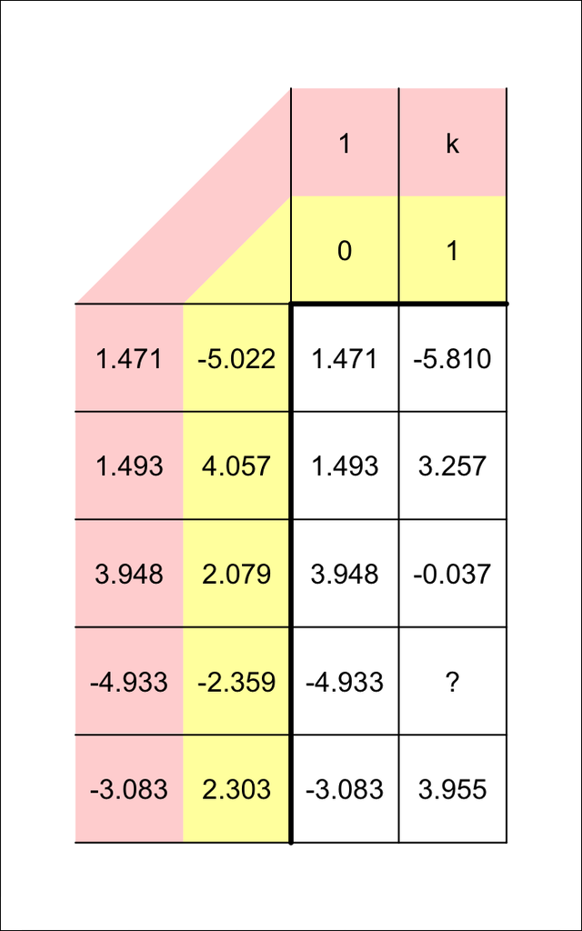

What is the new y coordinate when point $(-4.933, -2.359)$ undergoes the vertical shear transformation with $k=-0.536$?

The vertical shear transformation matrix:

$$T=\begin{bmatrix}
1 & -0.536\\
0 & 1
\end{bmatrix}$$

We are looking for the new y coordinate after point $(-4.933, -2.359)$ undergoes the shear transformation. Use column 2 of $T$:

$$(-4.933)(-0.536)~+~(-2.359)(1)$$

The new y coordinate is 0.285088.

A video-game developer is hoping to apply a horizontal [shear](https://en.wikipedia.org/wiki/Shear_mapping) to a set of points by using matrix multiplication.

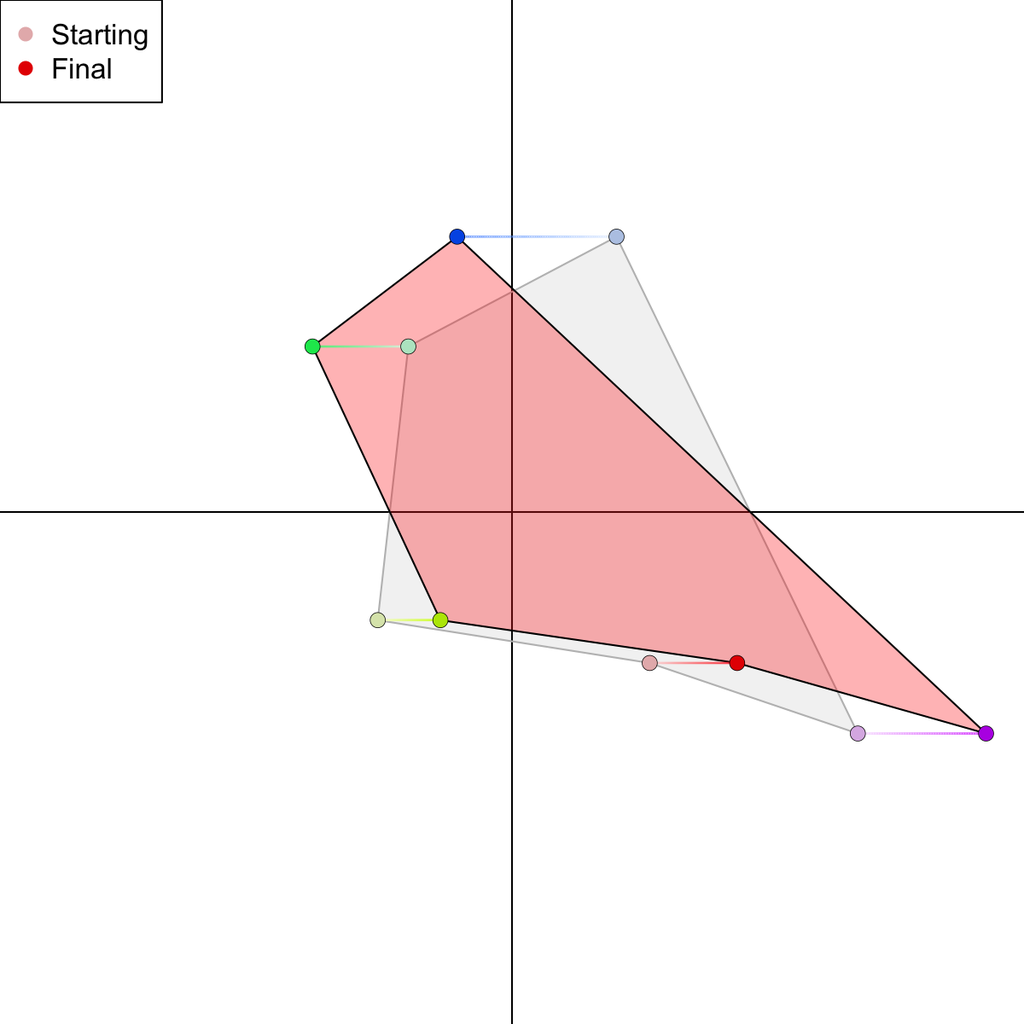

The starting points are stored as rows in a 5 $\times$ 2 matrix $S$.

$$S=\begin{bmatrix}
2.176 & -2.386\\
-2.121 & -1.709\\
-1.638 & 2.615\\
1.652 & 4.35\\
5.464 & -3.5
\end{bmatrix}$$

The horizontal shear matrix can be found by using $k=-0.579$ in the formula matrix.

$$T~=~\begin{bmatrix}
1 & 0\\
k & 1
\end{bmatrix}$$

The final points (in matrix $F$) are found by multiplying $S\cdot T$.

$$F=S\cdot T$$

That multiplication can be done using the diagram below.

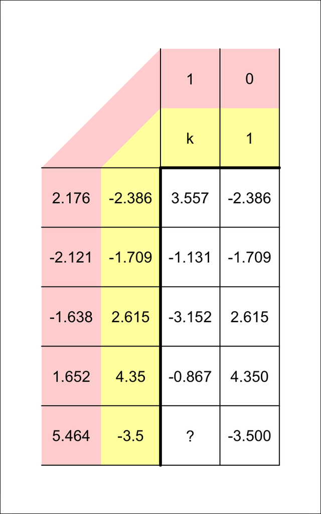

What is the new x coordinate when point $(5.464, -3.5)$ undergoes the horizontal shear transformation with $k=-0.579$?

The horizontal shear transformation matrix:

$$T=\begin{bmatrix}
1 & 0\\
-0.579 & 1
\end{bmatrix}$$

We are looking for the new x coordinate after point $(5.464, -3.5)$ undergoes the shear transformation. Use column 1 of $T$:

$$(5.464)(1)~+~(-3.5)(-0.579)$$

The new x coordinate is 7.4905.

A video-game developer is hoping to apply a horizontal [shear](https://en.wikipedia.org/wiki/Shear_mapping) to a set of points by using matrix multiplication.

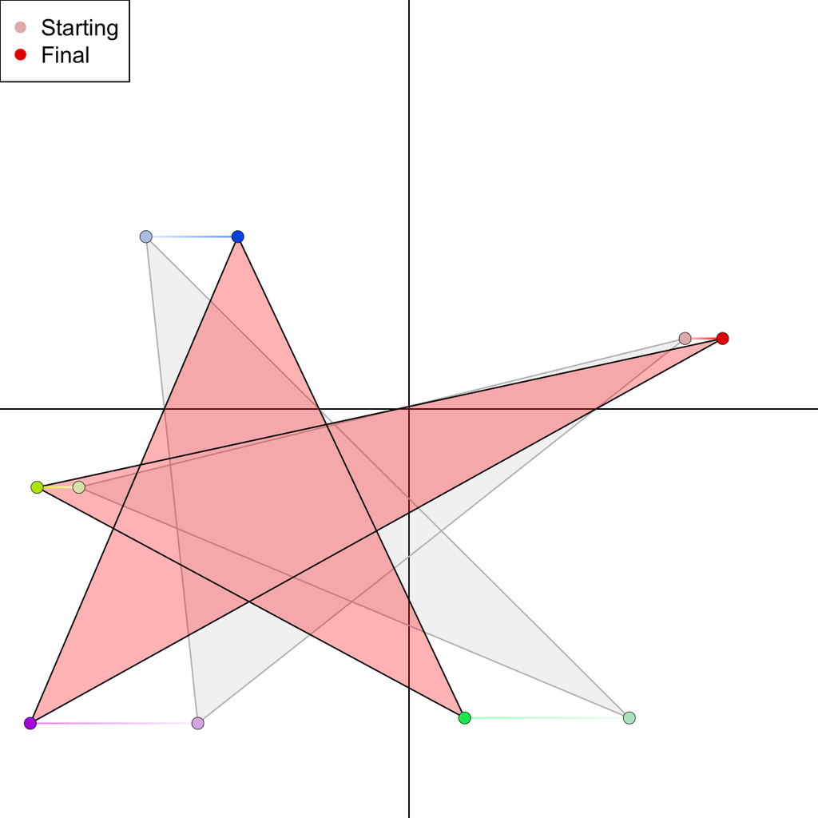

The starting points are stored as rows in a 5 $\times$ 2 matrix $S$.

$$S=\begin{bmatrix}
4.926 & 1.258\\
-5.891 & -1.397\\
3.932 & -5.513\\
-4.694 & 3.075\\
-3.768 & -5.609
\end{bmatrix}$$

The horizontal shear matrix can be found by using $k=0.533$ in the formula matrix.

$$T~=~\begin{bmatrix}
1 & 0\\
k & 1
\end{bmatrix}$$

The final points (in matrix $F$) are found by multiplying $S\cdot T$.

$$F=S\cdot T$$

That multiplication can be done using the diagram below.

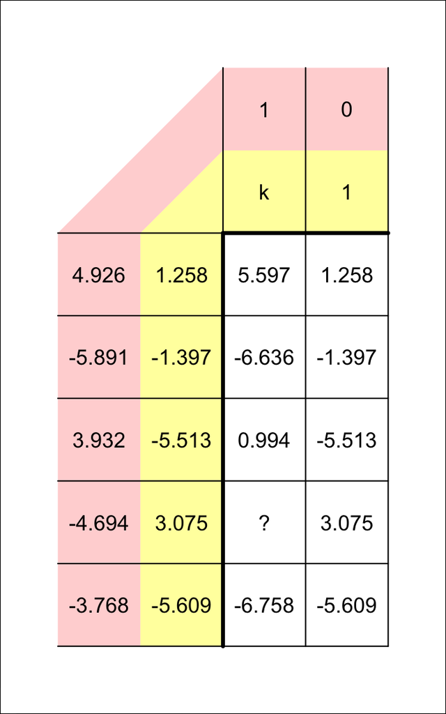

What is the new x coordinate when point $(-4.694, 3.075)$ undergoes the horizontal shear transformation with $k=0.533$?

The horizontal shear transformation matrix:

$$T=\begin{bmatrix}
1 & 0\\
0.533 & 1
\end{bmatrix}$$

We are looking for the new x coordinate after point $(-4.694, 3.075)$ undergoes the shear transformation. Use column 1 of $T$:

$$(-4.694)(1)~+~(3.075)(0.533)$$

The new x coordinate is -3.055025.

A video-game developer is hoping to apply a [squeeze map](https://en.wikipedia.org/wiki/Squeeze_mapping) to a set of points by using matrix multiplication. Interestingly, during a squeeze map, the area remains constant.

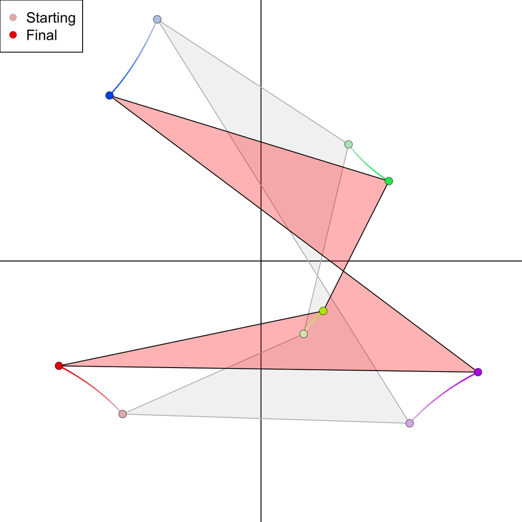

The starting points are stored as rows in a 5 $\times$ 2 matrix $S$.

$$S=\begin{bmatrix}
-3.432 & -3.796\\
1.057 & -1.808\\
2.171 & 2.892\\
-2.573 & 5.993\\
3.686 & -4.024
\end{bmatrix}$$

The squeeze matrix can be found by using $k=1.46$ in the formula below.

$$T~=~\begin{bmatrix}
k & 0\\
0 & 1/k
\end{bmatrix}$$

The final points (in matrix $F$) are found by multiplying $S\cdot T$.

$$F=S\cdot T$$

That multiplication can be done using the diagram below.

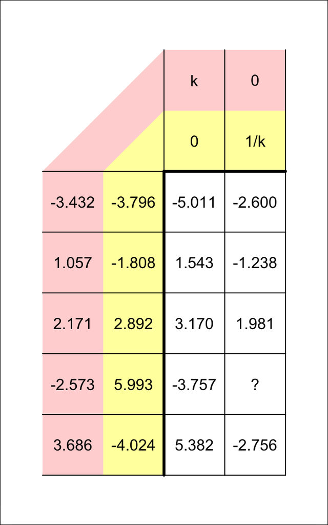

What is the new y coordinate when point $(-2.573, 5.993)$ undergoes the squeeze transformation with $k=1.46$?

The squeeze transformation matrix:

$$T=\begin{bmatrix}
1.46 & 0\\
0 & 0.684931506849315
\end{bmatrix}$$

We are looking for the new y coordinate after point $(-2.573, 5.993)$ undergoes the squeeze mapping. Use column 2 of $T$:

$$(-2.573)(0)~+~(5.993)(0.6849315)$$

The new y coordinate is 4.1047945.

A video-game developer is hoping to apply a [squeeze map](https://en.wikipedia.org/wiki/Squeeze_mapping) to a set of points by using matrix multiplication. Interestingly, during a squeeze map, the area remains constant.

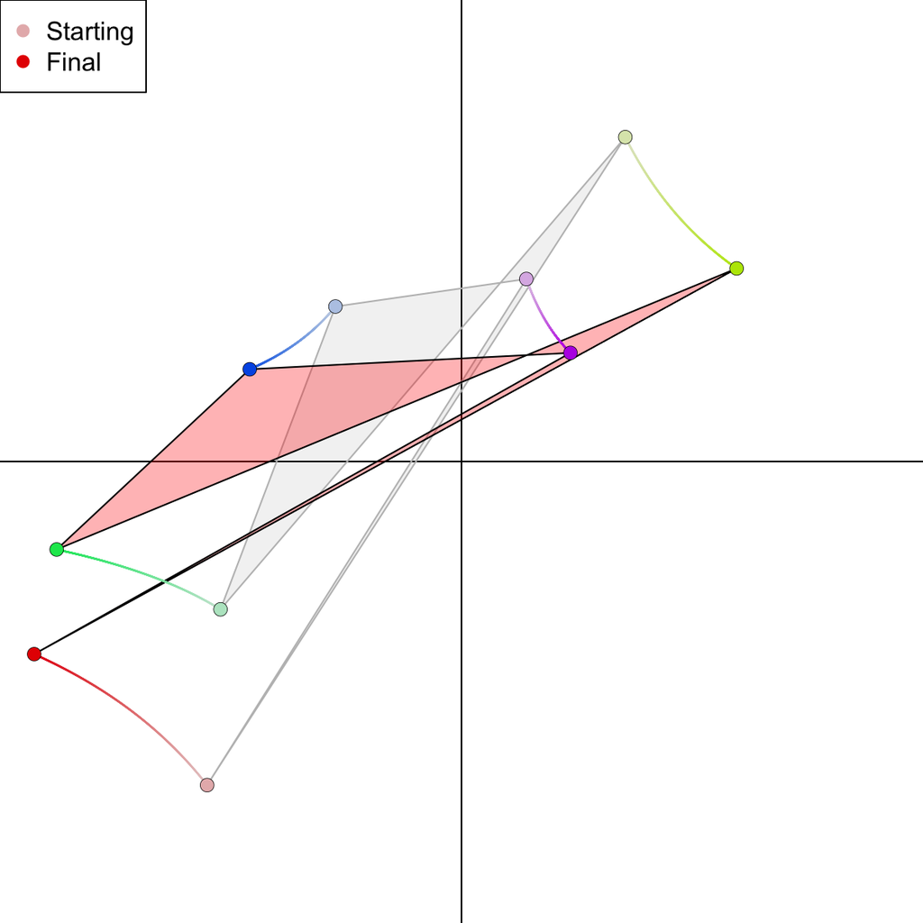

The starting points are stored as rows in a 5 $\times$ 2 matrix $S$.

$$S=\begin{bmatrix}
-4.451 & -5.663\\
2.866 & 5.676\\
-4.217 & -2.587\\
-2.206 & 2.712\\
1.135 & 3.194
\end{bmatrix}$$

The squeeze matrix can be found by using $k=1.68$ in the formula below.

$$T~=~\begin{bmatrix}
k & 0\\
0 & 1/k
\end{bmatrix}$$

The final points (in matrix $F$) are found by multiplying $S\cdot T$.

$$F=S\cdot T$$

That multiplication can be done using the diagram below.

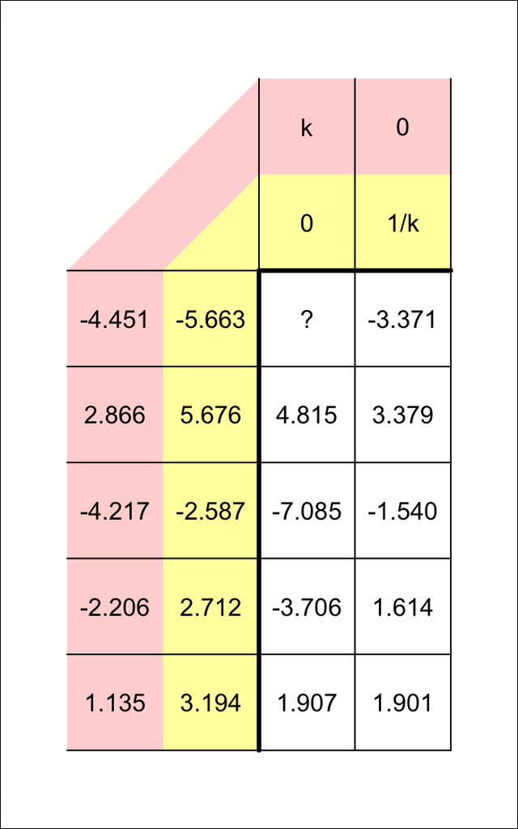

What is the new x coordinate when point $(-4.451, -5.663)$ undergoes the squeeze transformation with $k=1.68$?

The squeeze transformation matrix:

$$T=\begin{bmatrix}
1.68 & 0\\
0 & 0.595238095238095
\end{bmatrix}$$

We are looking for the new x coordinate after point $(-4.451, -5.663)$ undergoes the squeeze mapping. Use column 1 of $T$:

$$(-4.451)(1.68)~+~(-5.663)(0)$$

The new x coordinate is -7.47768.

A video-game developer is hoping to apply a [squeeze map](https://en.wikipedia.org/wiki/Squeeze_mapping) to a set of points by using matrix multiplication. Interestingly, during a squeeze map, the area remains constant.

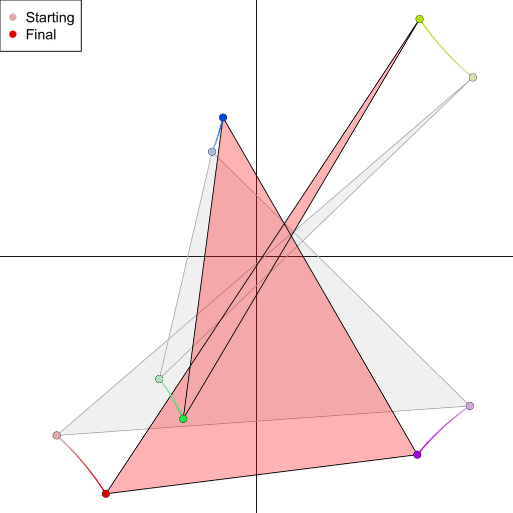

The starting points are stored as rows in a 5 $\times$ 2 matrix $S$.

$$S=\begin{bmatrix}
-5.445 & -4.876\\
5.895 & 4.88\\
-2.648 & -3.337\\
-1.209 & 2.856\\
5.813 & -4.072
\end{bmatrix}$$

The squeeze matrix can be found by using $k=0.754$ in the formula below.

$$T~=~\begin{bmatrix}
k & 0\\
0 & 1/k
\end{bmatrix}$$

The final points (in matrix $F$) are found by multiplying $S\cdot T$.

$$F=S\cdot T$$

That multiplication can be done using the diagram below.

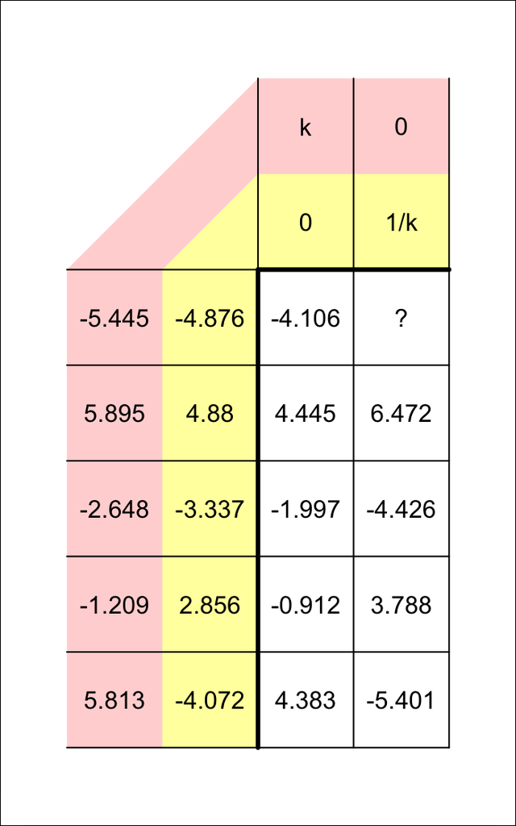

What is the new y coordinate when point $(-5.445, -4.876)$ undergoes the squeeze transformation with $k=0.754$?

The squeeze transformation matrix:

$$T=\begin{bmatrix}
0.754 & 0\\
0 & 1.3262599469496
\end{bmatrix}$$

We are looking for the new y coordinate after point $(-5.445, -4.876)$ undergoes the squeeze mapping. Use column 2 of $T$:

$$(-5.445)(0)~+~(-4.876)(1.3262599)$$

The new y coordinate is -6.4668435.

A video-game developer is hoping to apply a [squeeze map](https://en.wikipedia.org/wiki/Squeeze_mapping) to a set of points by using matrix multiplication. Interestingly, during a squeeze map, the area remains constant.

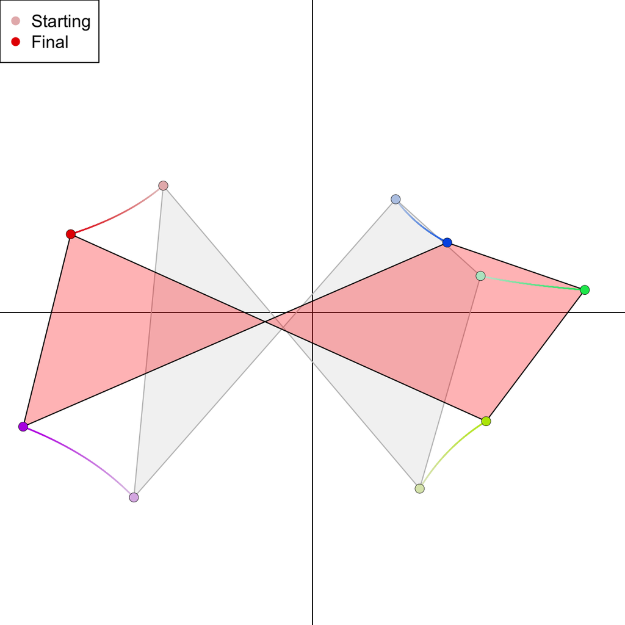

The starting points are stored as rows in a 5 $\times$ 2 matrix $S$.

$$S=\begin{bmatrix}
-4.691 & 3.988\\
3.369 & -5.537\\
5.284 & 1.149\\
2.615 & 3.56\\
-5.615 & -5.814
\end{bmatrix}$$

The squeeze matrix can be found by using $k=1.62$ in the formula below.

$$T~=~\begin{bmatrix}
k & 0\\
0 & 1/k
\end{bmatrix}$$

The final points (in matrix $F$) are found by multiplying $S\cdot T$.

$$F=S\cdot T$$

That multiplication can be done using the diagram below.

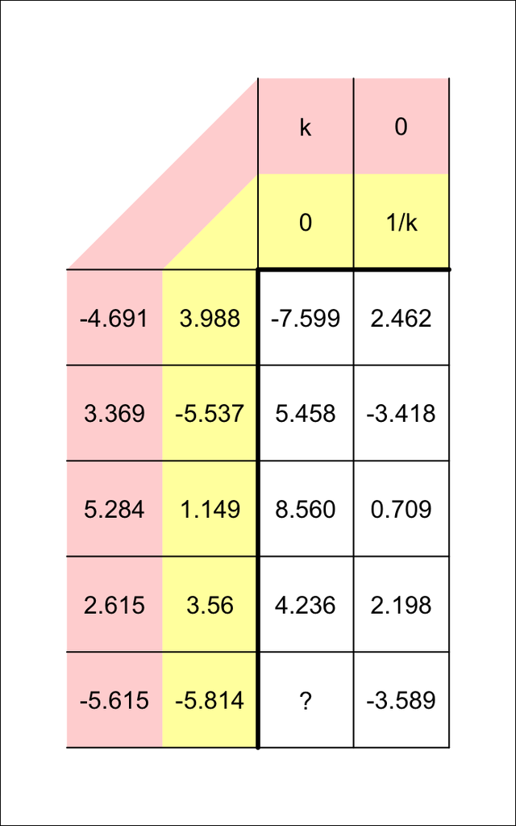

What is the new x coordinate when point $(-5.615, -5.814)$ undergoes the squeeze transformation with $k=1.62$?

The squeeze transformation matrix:

$$T=\begin{bmatrix}
1.62 & 0\\
0 & 0.617283950617284
\end{bmatrix}$$

We are looking for the new x coordinate after point $(-5.615, -5.814)$ undergoes the squeeze mapping. Use column 1 of $T$:

$$(-5.615)(1.62)~+~(-5.814)(0)$$

The new x coordinate is -9.0963.

A video-game developer is hoping to apply a [squeeze map](https://en.wikipedia.org/wiki/Squeeze_mapping) to a set of points by using matrix multiplication. Interestingly, during a squeeze map, the area remains constant.

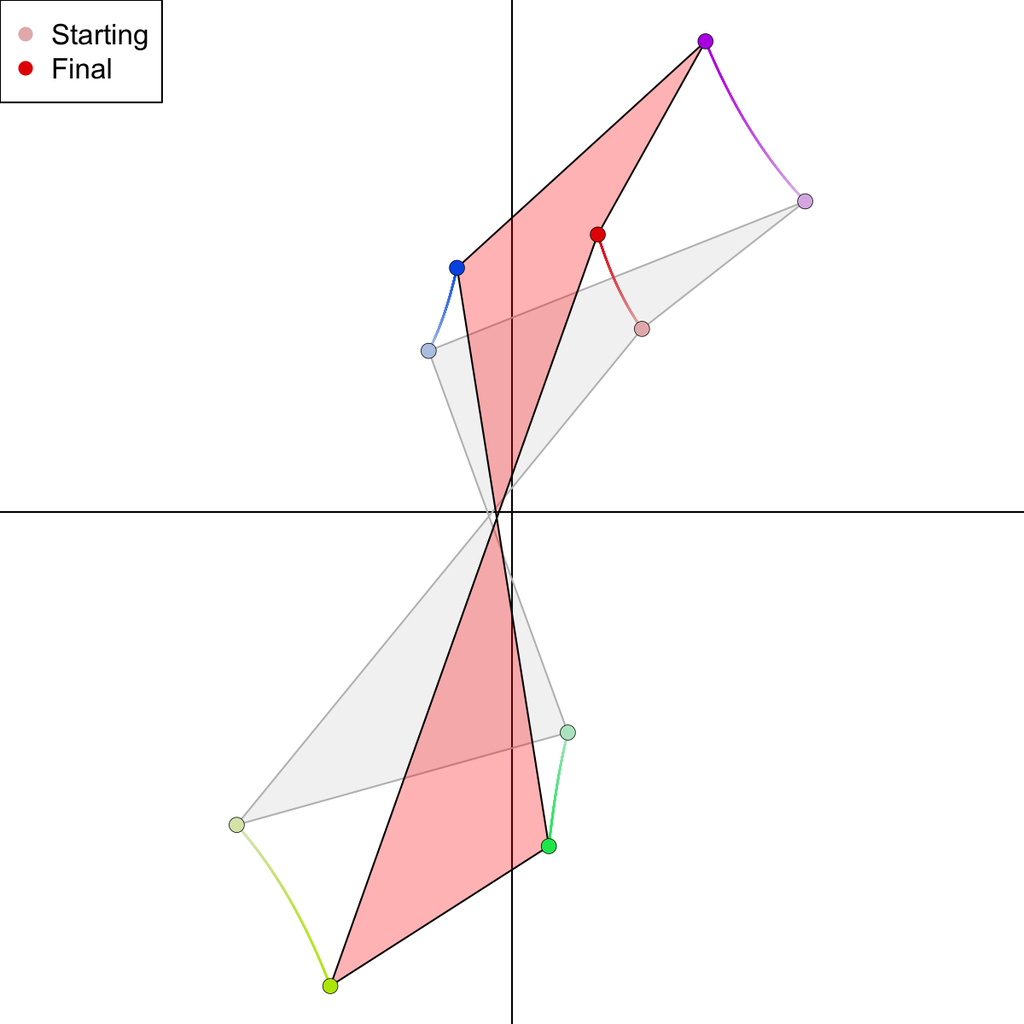

The starting points are stored as rows in a 5 $\times$ 2 matrix $S$.

$$S=\begin{bmatrix}
2.33 & 3.282\\
-4.934 & -5.608\\
1.001 & -3.953\\
-1.494 & 2.888\\
5.255 & 5.568
\end{bmatrix}$$

The squeeze matrix can be found by using $k=0.66$ in the formula below.

$$T~=~\begin{bmatrix}
k & 0\\
0 & 1/k
\end{bmatrix}$$

The final points (in matrix $F$) are found by multiplying $S\cdot T$.

$$F=S\cdot T$$

That multiplication can be done using the diagram below.

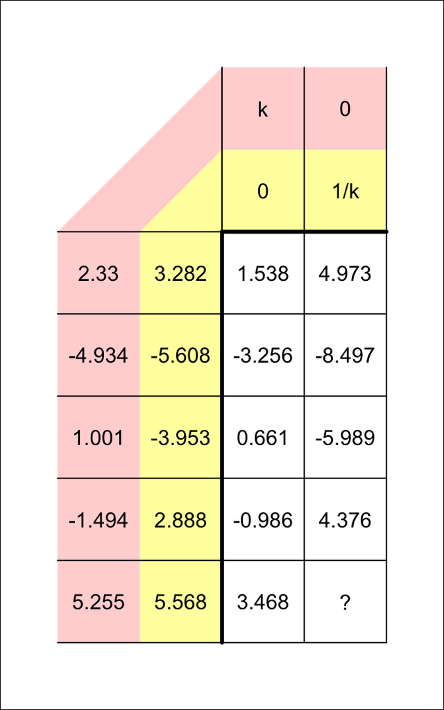

What is the new y coordinate when point $(5.255, 5.568)$ undergoes the squeeze transformation with $k=0.66$?

The squeeze transformation matrix:

$$T=\begin{bmatrix}
0.66 & 0\\
0 & 1.51515151515152
\end{bmatrix}$$

We are looking for the new y coordinate after point $(5.255, 5.568)$ undergoes the squeeze mapping. Use column 2 of $T$:

$$(5.255)(0)~+~(5.568)(1.5151515)$$

The new y coordinate is 8.4363636.

A video-game developer is hoping to apply a [squeeze map](https://en.wikipedia.org/wiki/Squeeze_mapping) to a set of points by using matrix multiplication. Interestingly, during a squeeze map, the area remains constant.

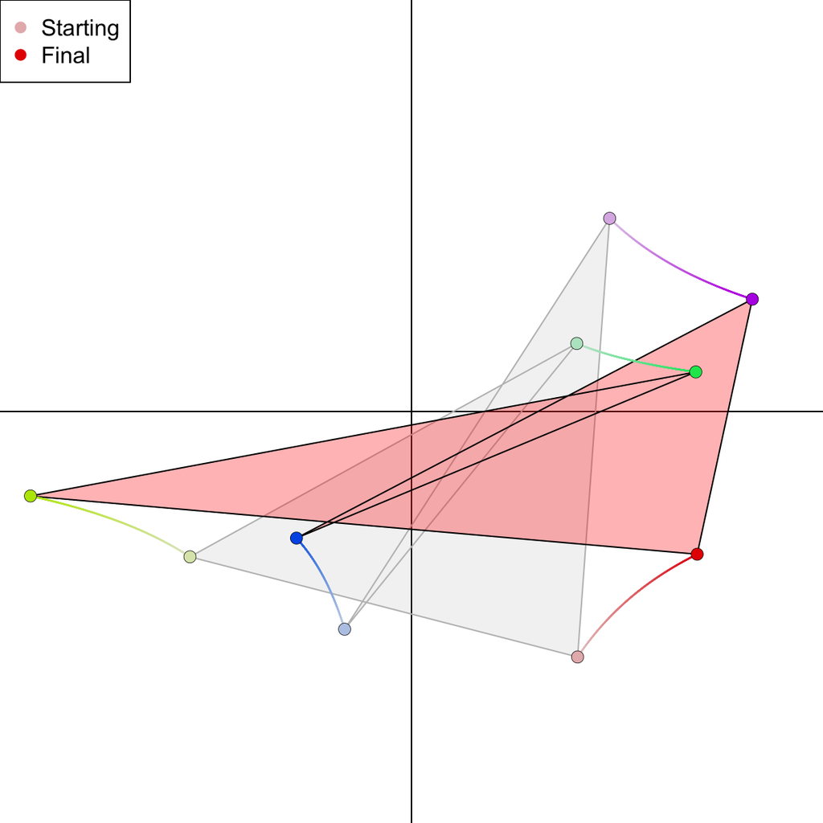

The starting points are stored as rows in a 5 $\times$ 2 matrix $S$.

$$S=\begin{bmatrix}
4.031 & -5.957\\
-5.376 & -3.526\\
4.011 & 1.651\\
-1.623 & -5.284\\
4.809 & 4.687
\end{bmatrix}$$

The squeeze matrix can be found by using $k=1.72$ in the formula below.

$$T~=~\begin{bmatrix}
k & 0\\
0 & 1/k
\end{bmatrix}$$

The final points (in matrix $F$) are found by multiplying $S\cdot T$.

$$F=S\cdot T$$

That multiplication can be done using the diagram below.

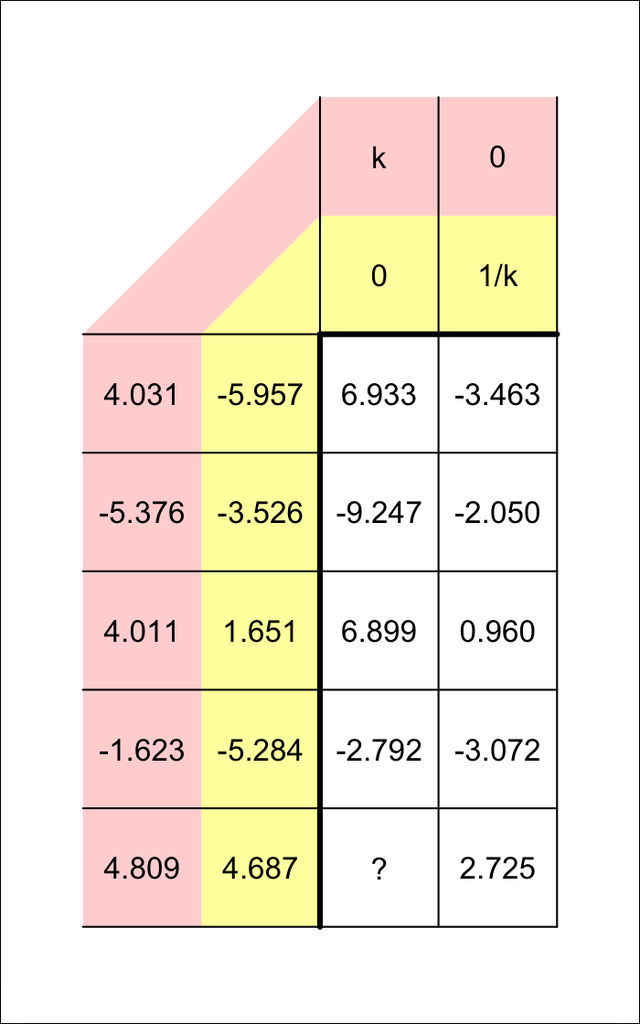

What is the new x coordinate when point $(4.809, 4.687)$ undergoes the squeeze transformation with $k=1.72$?

The squeeze transformation matrix:

$$T=\begin{bmatrix}
1.72 & 0\\
0 & 0.581395348837209
\end{bmatrix}$$

We are looking for the new x coordinate after point $(4.809, 4.687)$ undergoes the squeeze mapping. Use column 1 of $T$:

$$(4.809)(1.72)~+~(4.687)(0)$$

The new x coordinate is 8.27148.

A video-game developer is hoping to apply a [squeeze map](https://en.wikipedia.org/wiki/Squeeze_mapping) to a set of points by using matrix multiplication. Interestingly, during a squeeze map, the area remains constant.

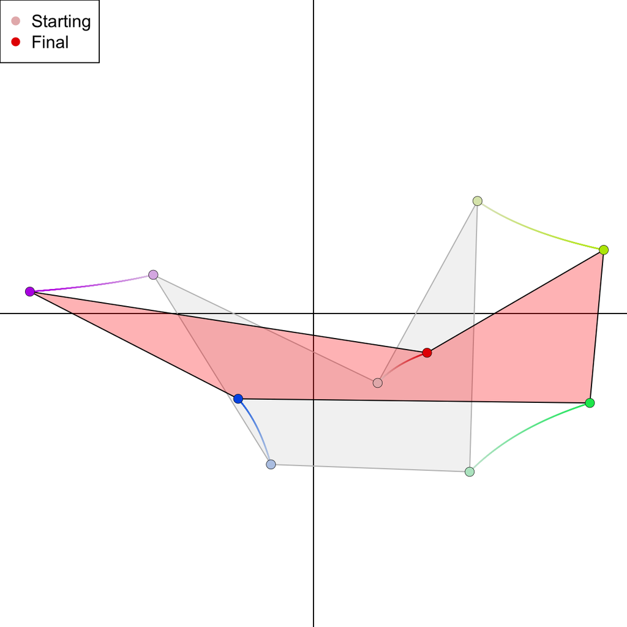

The starting points are stored as rows in a 5 $\times$ 2 matrix $S$.

$$S=\begin{bmatrix}
2.142 & -2.319\\
5.475 & 3.756\\
5.213 & -5.285\\
-1.421 & -5.039\\
-5.349 & 1.292
\end{bmatrix}$$

The squeeze matrix can be found by using $k=1.77$ in the formula below.

$$T~=~\begin{bmatrix}
k & 0\\
0 & 1/k
\end{bmatrix}$$

The final points (in matrix $F$) are found by multiplying $S\cdot T$.

$$F=S\cdot T$$

That multiplication can be done using the diagram below.

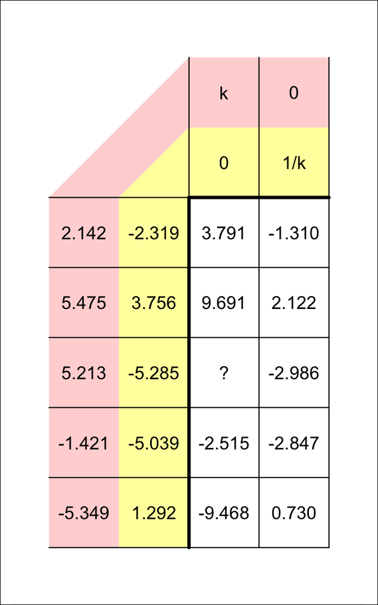

What is the new x coordinate when point $(5.213, -5.285)$ undergoes the squeeze transformation with $k=1.77$?

The squeeze transformation matrix:

$$T=\begin{bmatrix}
1.77 & 0\\
0 & 0.564971751412429
\end{bmatrix}$$

We are looking for the new x coordinate after point $(5.213, -5.285)$ undergoes the squeeze mapping. Use column 1 of $T$:

$$(5.213)(1.77)~+~(-5.285)(0)$$

The new x coordinate is 9.22701.

A video-game developer is hoping to apply a [squeeze map](https://en.wikipedia.org/wiki/Squeeze_mapping) to a set of points by using matrix multiplication. Interestingly, during a squeeze map, the area remains constant.

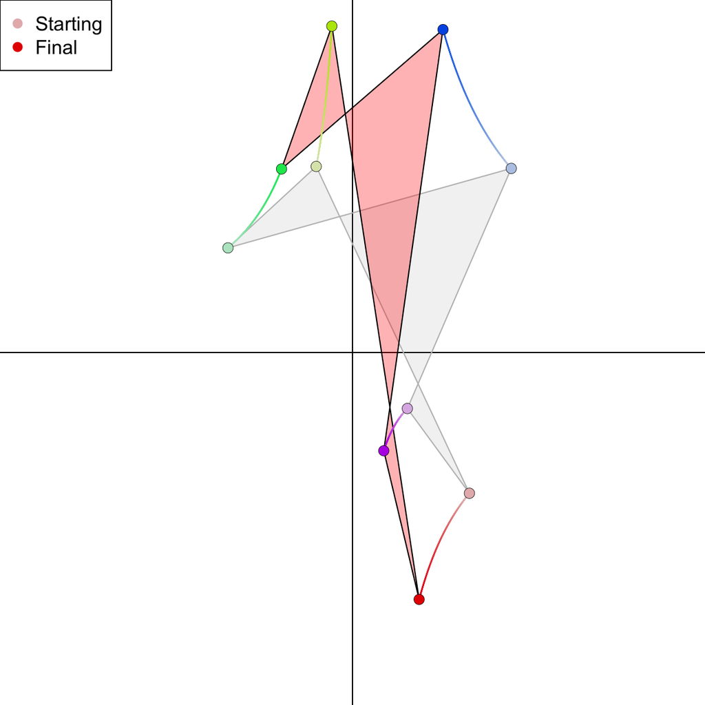

The starting points are stored as rows in a 5 $\times$ 2 matrix $S$.

$$S=\begin{bmatrix}
3.769 & -4.538\\
-1.17 & 5.998\\
-4.014 & 3.373\\
5.119 & 5.935\\
1.769 & -1.806
\end{bmatrix}$$

The squeeze matrix can be found by using $k=0.57$ in the formula below.

$$T~=~\begin{bmatrix}
k & 0\\
0 & 1/k
\end{bmatrix}$$

The final points (in matrix $F$) are found by multiplying $S\cdot T$.

$$F=S\cdot T$$

That multiplication can be done using the diagram below.

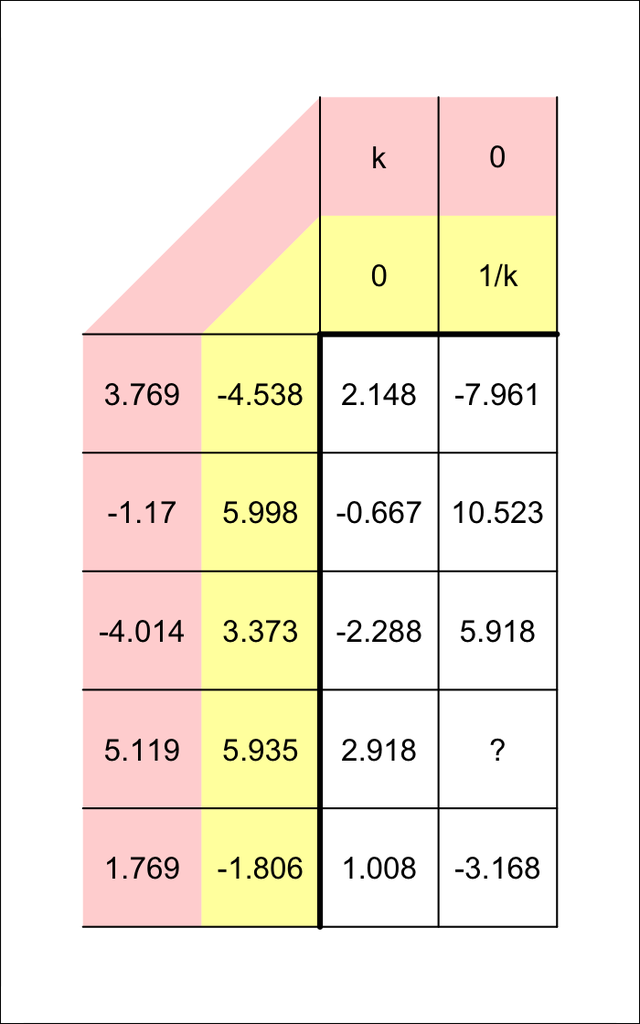

What is the new y coordinate when point $(5.119, 5.935)$ undergoes the squeeze transformation with $k=0.57$?

The squeeze transformation matrix:

$$T=\begin{bmatrix}
0.57 & 0\\
0 & 1.75438596491228
\end{bmatrix}$$

We are looking for the new y coordinate after point $(5.119, 5.935)$ undergoes the squeeze mapping. Use column 2 of $T$:

$$(5.119)(0)~+~(5.935)(1.754386)$$

The new y coordinate is 10.4122807.

A video-game developer is hoping to apply a [squeeze map](https://en.wikipedia.org/wiki/Squeeze_mapping) to a set of points by using matrix multiplication. Interestingly, during a squeeze map, the area remains constant.

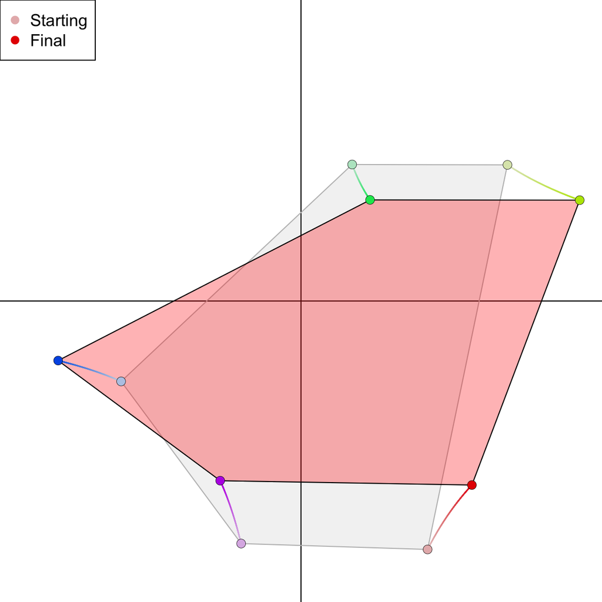

The starting points are stored as rows in a 5 $\times$ 2 matrix $S$.

$$S=\begin{bmatrix}
2.517 & -4.94\\
4.105 & 2.707\\
1.017 & 2.714\\
-3.577 & -1.599\\
-1.19 & -4.823
\end{bmatrix}$$

The squeeze matrix can be found by using $k=1.35$ in the formula below.

$$T~=~\begin{bmatrix}
k & 0\\
0 & 1/k
\end{bmatrix}$$

The final points (in matrix $F$) are found by multiplying $S\cdot T$.

$$F=S\cdot T$$

That multiplication can be done using the diagram below.

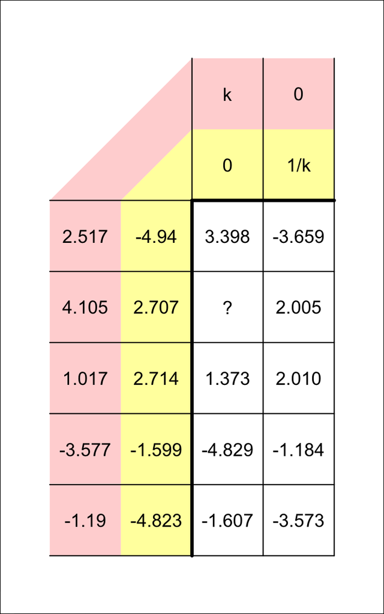

What is the new x coordinate when point $(4.105, 2.707)$ undergoes the squeeze transformation with $k=1.35$?

The squeeze transformation matrix:

$$T=\begin{bmatrix}
1.35 & 0\\
0 & 0.740740740740741
\end{bmatrix}$$

We are looking for the new x coordinate after point $(4.105, 2.707)$ undergoes the squeeze mapping. Use column 1 of $T$:

$$(4.105)(1.35)~+~(2.707)(0)$$

The new x coordinate is 5.54175.

A video-game developer is hoping to apply a [squeeze map](https://en.wikipedia.org/wiki/Squeeze_mapping) to a set of points by using matrix multiplication. Interestingly, during a squeeze map, the area remains constant.

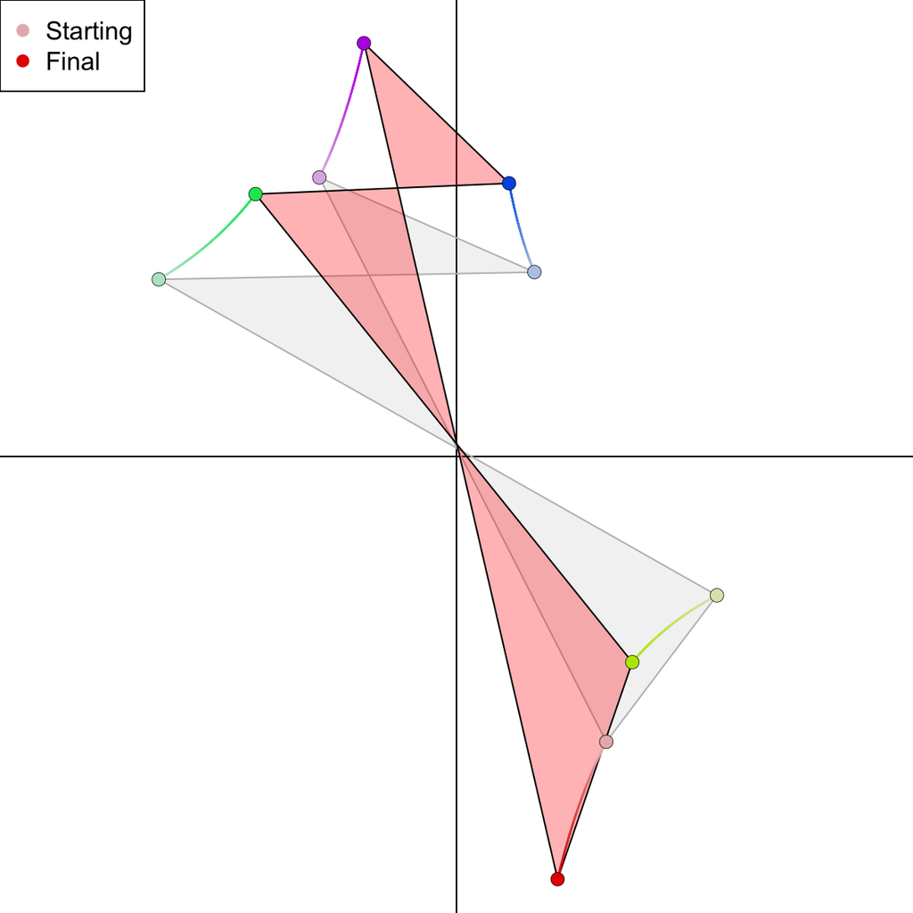

The starting points are stored as rows in a 5 $\times$ 2 matrix $S$.

$$S=\begin{bmatrix}
2.829 & -5.388\\
4.918 & -2.622\\
-5.623 & 3.345\\
1.471 & 3.483\\
-2.59 & 5.269
\end{bmatrix}$$

The squeeze matrix can be found by using $k=0.675$ in the formula below.

$$T~=~\begin{bmatrix}
k & 0\\
0 & 1/k
\end{bmatrix}$$

The final points (in matrix $F$) are found by multiplying $S\cdot T$.

$$F=S\cdot T$$

That multiplication can be done using the diagram below.

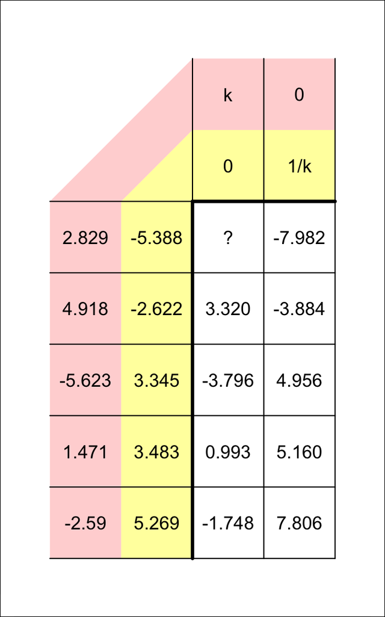

What is the new x coordinate when point $(2.829, -5.388)$ undergoes the squeeze transformation with $k=0.675$?

The squeeze transformation matrix:

$$T=\begin{bmatrix}
0.675 & 0\\
0 & 1.48148148148148
\end{bmatrix}$$

We are looking for the new x coordinate after point $(2.829, -5.388)$ undergoes the squeeze mapping. Use column 1 of $T$:

$$(2.829)(0.675)~+~(-5.388)(0)$$

The new x coordinate is 1.909575.

A video-game developer is hoping to apply an [oblique projection](https://en.wikipedia.org/wiki/Oblique_projection) to show a set of 3D points as a 2D image. The starting points are stored as rows in a 5 $\times$ 3 matrix $S$.

$$S=\begin{bmatrix}
-0.0146 & -0.9251 & -1.4643\\
-1.2295 & -1.2161 & 0.0976\\
-1.5429 & 0.7553 & 0.2212\\
-0.3281 & 1.0464 & -1.3407\\
0.7788 & 0.0849 & 0.6215
\end{bmatrix}$$

The oblique projection matrix $P$ has two key parameters: $\theta$ and $r$. For this problem, use $\theta=0.9122$ and $r=0.5343$.

$$P~=~\begin{bmatrix}
1 & 0\\
0 & 1\\
r\cdot\cos(\theta) & r\cdot\sin(\theta)
\end{bmatrix}$$

The final points (in matrix $F$) are found by multiplying $S\cdot P$.

$$F=S\cdot P$$

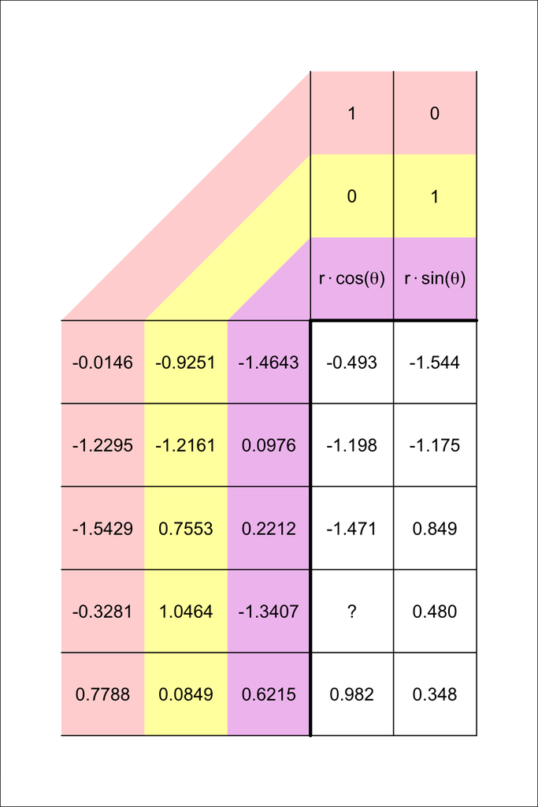

What is the new $x$ coordinate when point $(-0.3281, 1.0464, -1.3407)$ is projected using the oblique projection with $\theta=0.9122$ and $r=0.5343$?

Find the projection matrix by pluggin in $\theta=0.9122$ and $r=0.5343$.

$$P=\begin{bmatrix}
1 & 0\\
0 & 1\\
0.32699553105801 & 0.422552260280418
\end{bmatrix}$$

We use row 4 of the points matrix and column 1 of the projection matrix.

$$(-0.3281)(1)~+~(1.0464)(0)~+~(-1.3407)(0.3269955)$$

Thus, $x=-0.7665029$.

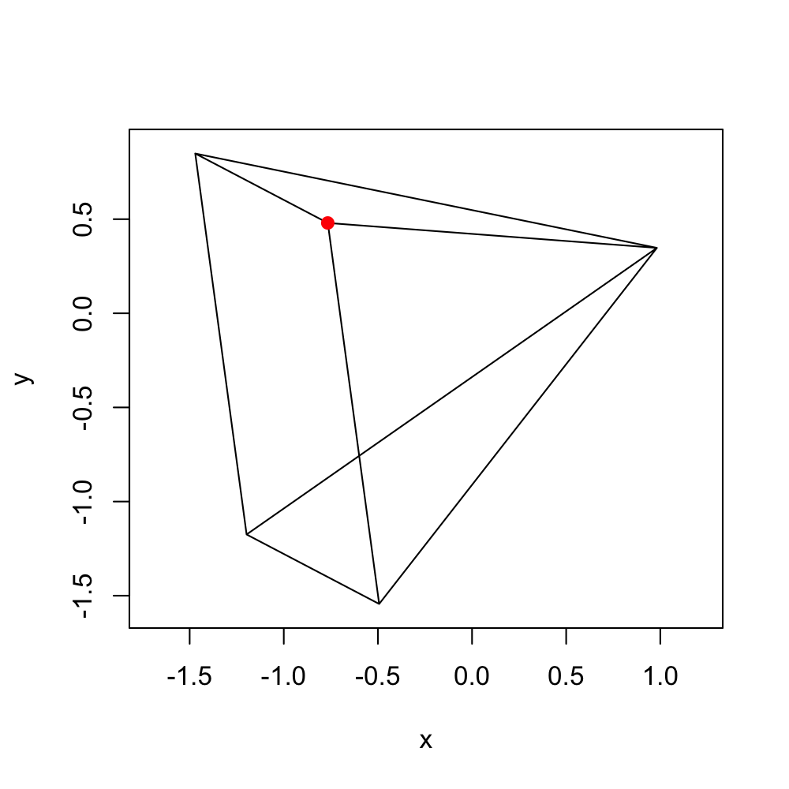

A video-game developer is hoping to apply an [oblique projection](https://en.wikipedia.org/wiki/Oblique_projection) to show a set of 3D points as a 2D image. The starting points are stored as rows in a 5 $\times$ 3 matrix $S$.

$$S=\begin{bmatrix}
-0.0685 & -1.7264 & -0.1222\\
1.4327 & -0.685 & 0.6914\\
0.1119 & 0.4568 & 1.667\\
-1.3893 & -0.5846 & 0.8534\\
-0.0217 & 0.6348 & -0.7724
\end{bmatrix}$$

The oblique projection matrix $P$ has two key parameters: $\theta$ and $r$. For this problem, use $\theta=0.9058$ and $r=0.4073$.

$$P~=~\begin{bmatrix}
1 & 0\\
0 & 1\\
r\cdot\cos(\theta) & r\cdot\sin(\theta)
\end{bmatrix}$$

The final points (in matrix $F$) are found by multiplying $S\cdot P$.

$$F=S\cdot P$$

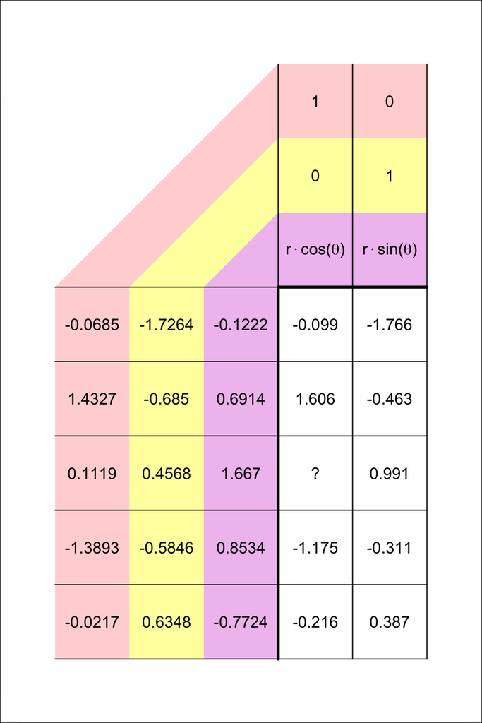

What is the new $x$ coordinate when point $(0.1119, 0.4568, 1.667)$ is projected using the oblique projection with $\theta=0.9058$ and $r=0.4073$?

Find the projection matrix by pluggin in $\theta=0.9058$ and $r=0.4073$.

$$P=\begin{bmatrix}
1 & 0\\
0 & 1\\
0.251327007455054 & 0.320512129760618
\end{bmatrix}$$

We use row 3 of the points matrix and column 1 of the projection matrix.

$$(0.1119)(1)~+~(0.4568)(0)~+~(1.667)(0.251327)$$

Thus, $x=0.5308621$.

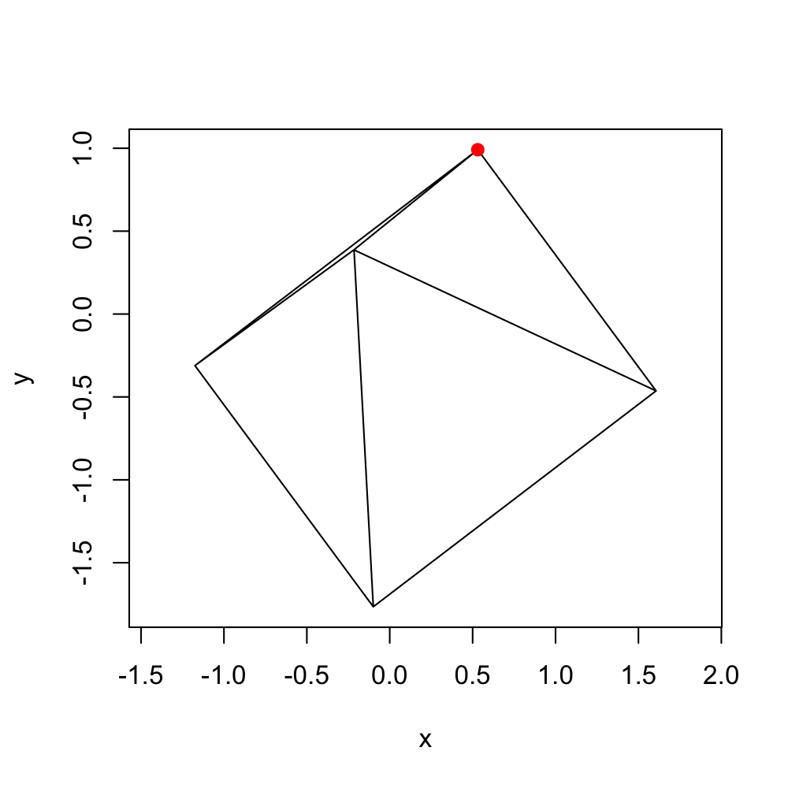

A video-game developer is hoping to apply an [oblique projection](https://en.wikipedia.org/wiki/Oblique_projection) to show a set of 3D points as a 2D image. The starting points are stored as rows in a 5 $\times$ 3 matrix $S$.

$$S=\begin{bmatrix}
-0.6182 & 1.1453 & 1.1429\\
0.1441 & 1.5992 & -0.6495\\
-0.9047 & 0.1085 & -1.473\\
-1.6669 & -0.3454 & 0.3194\\
0.7614 & -0.6269 & 0.1651
\end{bmatrix}$$

The oblique projection matrix $P$ has two key parameters: $\theta$ and $r$. For this problem, use $\theta=0.6846$ and $r=0.4867$.

$$P~=~\begin{bmatrix}
1 & 0\\
0 & 1\\
r\cdot\cos(\theta) & r\cdot\sin(\theta)
\end{bmatrix}$$

The final points (in matrix $F$) are found by multiplying $S\cdot P$.

$$F=S\cdot P$$

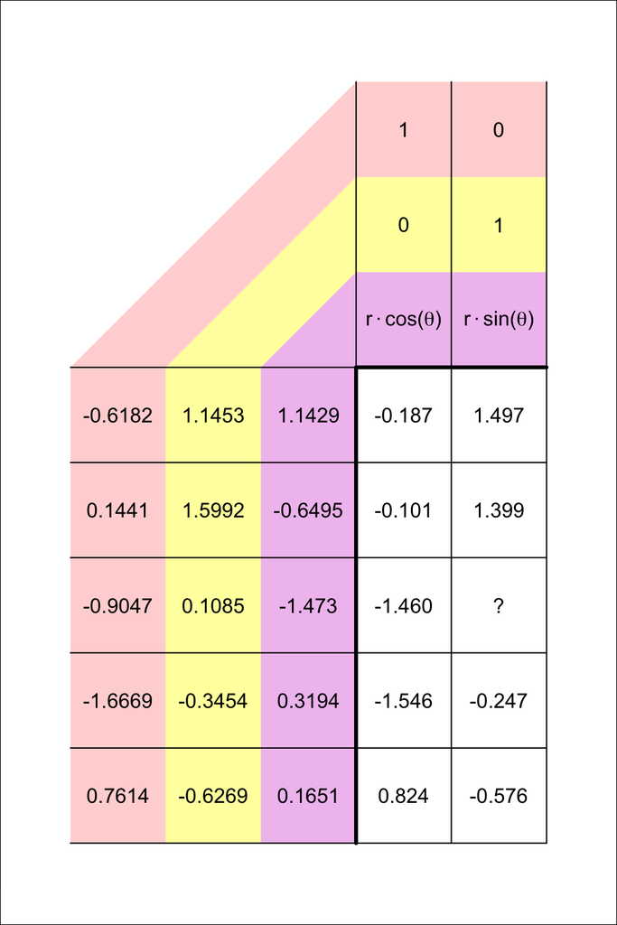

What is the new $y$ coordinate when point $(-0.9047, 0.1085, -1.473)$ is projected using the oblique projection with $\theta=0.6846$ and $r=0.4867$?

Find the projection matrix by pluggin in $\theta=0.6846$ and $r=0.4867$.

$$P=\begin{bmatrix}
1 & 0\\
0 & 1\\
0.377032888845464 & 0.307771166175202
\end{bmatrix}$$

We use row 3 of the points matrix and column 2 of the projection matrix.

$$(-0.9047)(0)~+~(0.1085)(1)~+~(-1.473)(0.3077712)$$

Thus, $y=-0.3448469$.

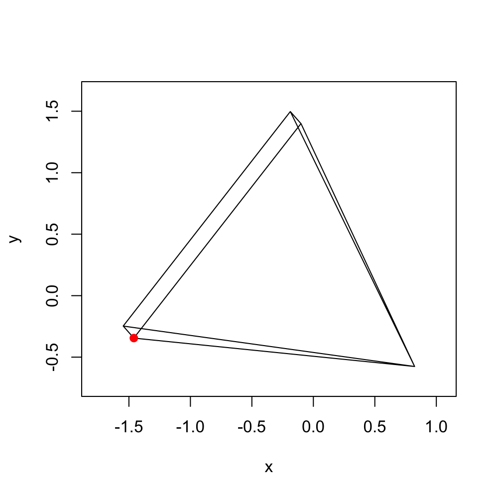

A video-game developer is hoping to apply an [oblique projection](https://en.wikipedia.org/wiki/Oblique_projection) to show a set of 3D points as a 2D image. The starting points are stored as rows in a 5 $\times$ 3 matrix $S$.

$$S=\begin{bmatrix}
0.5185 & 1.3709 & -0.9229\\
-1.3824 & 0.8066 & -0.6621\\
-1.0321 & 0.5274 & 1.2871\\
0.8688 & 1.0918 & 1.0263\\
0.2568 & -0.9492 & -0.1821
\end{bmatrix}$$

The oblique projection matrix $P$ has two key parameters: $\theta$ and $r$. For this problem, use $\theta=0.74$ and $r=0.5951$.

$$P~=~\begin{bmatrix}
1 & 0\\
0 & 1\\
r\cdot\cos(\theta) & r\cdot\sin(\theta)
\end{bmatrix}$$

The final points (in matrix $F$) are found by multiplying $S\cdot P$.

$$F=S\cdot P$$

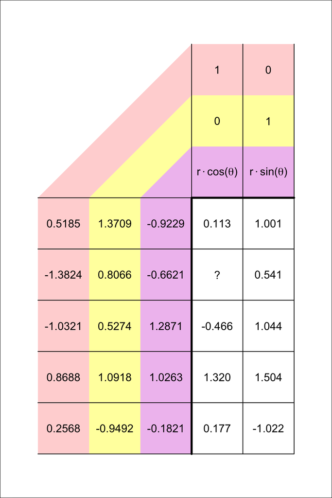

What is the new $x$ coordinate when point $(-1.3824, 0.8066, -0.6621)$ is projected using the oblique projection with $\theta=0.74$ and $r=0.5951$?

Find the projection matrix by pluggin in $\theta=0.74$ and $r=0.5951$.

$$P=\begin{bmatrix}
1 & 0\\
0 & 1\\
0.439462639299978 & 0.401268736209909
\end{bmatrix}$$

We use row 2 of the points matrix and column 1 of the projection matrix.

$$(-1.3824)(1)~+~(0.8066)(0)~+~(-0.6621)(0.4394626)$$

Thus, $x=-1.6733682$.

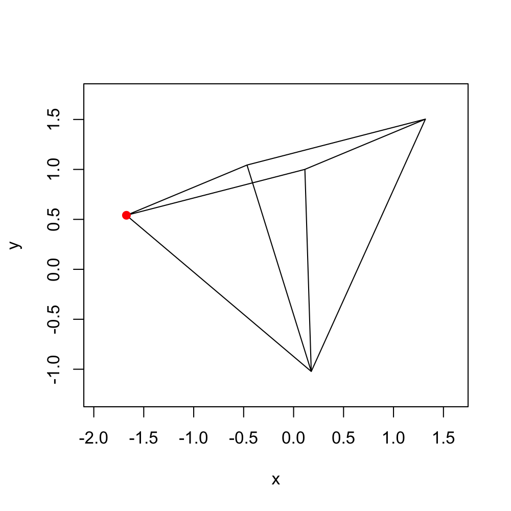

A video-game developer is hoping to apply an [oblique projection](https://en.wikipedia.org/wiki/Oblique_projection) to show a set of 3D points as a 2D image. The starting points are stored as rows in a 5 $\times$ 3 matrix $S$.

$$S=\begin{bmatrix}
0.7892 & -1.0056 & 1.1687\\
0.975 & -1.1768 & -0.8153\\
1.1905 & 0.8059 & -0.9661\\
1.0047 & 0.977 & 1.0179\\
-0.9898 & 0.0999 & -0.1013
\end{bmatrix}$$

The oblique projection matrix $P$ has two key parameters: $\theta$ and $r$. For this problem, use $\theta=0.6775$ and $r=0.2646$.

$$P~=~\begin{bmatrix}
1 & 0\\
0 & 1\\
r\cdot\cos(\theta) & r\cdot\sin(\theta)
\end{bmatrix}$$

The final points (in matrix $F$) are found by multiplying $S\cdot P$.

$$F=S\cdot P$$

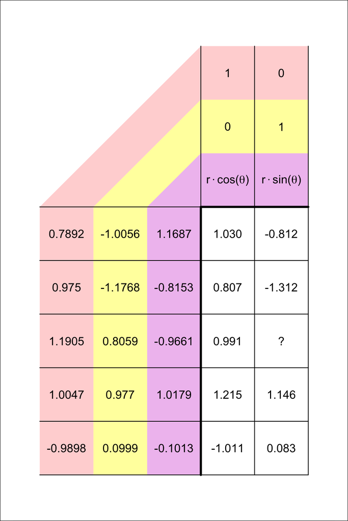

What is the new $y$ coordinate when point $(1.1905, 0.8059, -0.9661)$ is projected using the oblique projection with $\theta=0.6775$ and $r=0.2646$?

Find the projection matrix by pluggin in $\theta=0.6775$ and $r=0.2646$.

$$P=\begin{bmatrix}
1 & 0\\
0 & 1\\
0.206161044578499 & 0.165863750404668
\end{bmatrix}$$

We use row 3 of the points matrix and column 2 of the projection matrix.

$$(1.1905)(0)~+~(0.8059)(1)~+~(-0.9661)(0.1658638)$$

Thus, $y=0.645659$.

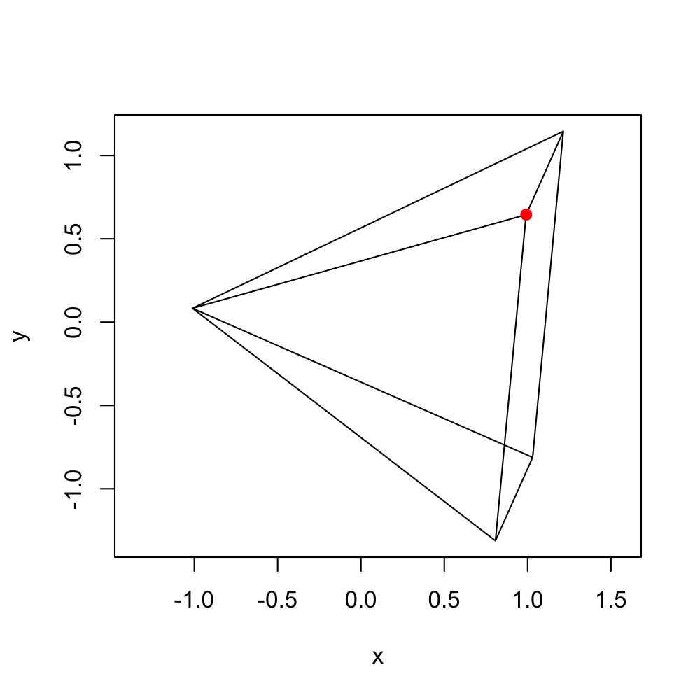

A video-game developer is hoping to apply an [oblique projection](https://en.wikipedia.org/wiki/Oblique_projection) to show a set of 3D points as a 2D image. The starting points are stored as rows in a 5 $\times$ 3 matrix $S$.

$$S=\begin{bmatrix}
0.9992 & 1.3243 & -0.4978\\
-0.8345 & 0.9354 & -1.1953\\
-1.4755 & 0.6104 & 0.6711\\
0.3582 & 0.9993 & 1.3686\\
0.2381 & -0.9674 & -0.0867
\end{bmatrix}$$

The oblique projection matrix $P$ has two key parameters: $\theta$ and $r$. For this problem, use $\theta=0.7759$ and $r=0.4453$.

$$P~=~\begin{bmatrix}
1 & 0\\
0 & 1\\
r\cdot\cos(\theta) & r\cdot\sin(\theta)
\end{bmatrix}$$

The final points (in matrix $F$) are found by multiplying $S\cdot P$.

$$F=S\cdot P$$

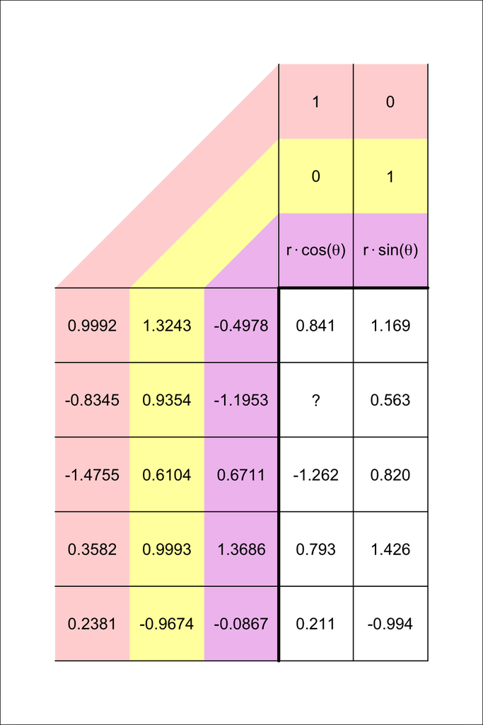

What is the new $x$ coordinate when point $(-0.8345, 0.9354, -1.1953)$ is projected using the oblique projection with $\theta=0.7759$ and $r=0.4453$?

Find the projection matrix by pluggin in $\theta=0.7759$ and $r=0.4453$.

$$P=\begin{bmatrix}
1 & 0\\
0 & 1\\
0.317851132448123 & 0.311869760639671
\end{bmatrix}$$

We use row 2 of the points matrix and column 1 of the projection matrix.

$$(-0.8345)(1)~+~(0.9354)(0)~+~(-1.1953)(0.3178511)$$

Thus, $x=-1.2144275$.

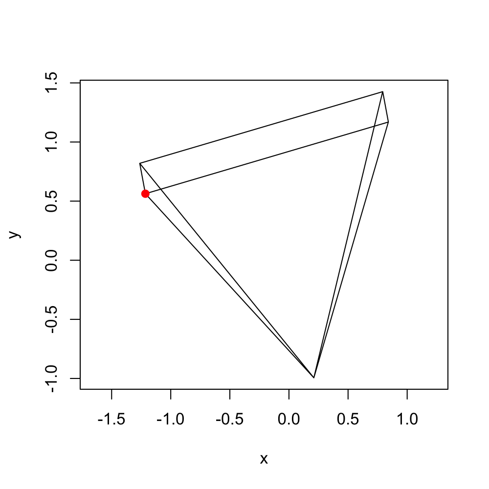

A video-game developer is hoping to apply an [oblique projection](https://en.wikipedia.org/wiki/Oblique_projection) to show a set of 3D points as a 2D image. The starting points are stored as rows in a 5 $\times$ 3 matrix $S$.

$$S=\begin{bmatrix}
0.1042 & -0.6159 & -1.6155\\
1.2972 & 0.787 & -0.8354\\
1.4895 & -0.3029 & 0.8305\\
0.2964 & -1.7058 & 0.0504\\
-0.7968 & 0.4594 & 0.3925
\end{bmatrix}$$

The oblique projection matrix $P$ has two key parameters: $\theta$ and $r$. For this problem, use $\theta=0.5697$ and $r=0.2265$.

$$P~=~\begin{bmatrix}
1 & 0\\
0 & 1\\
r\cdot\cos(\theta) & r\cdot\sin(\theta)
\end{bmatrix}$$

The final points (in matrix $F$) are found by multiplying $S\cdot P$.

$$F=S\cdot P$$

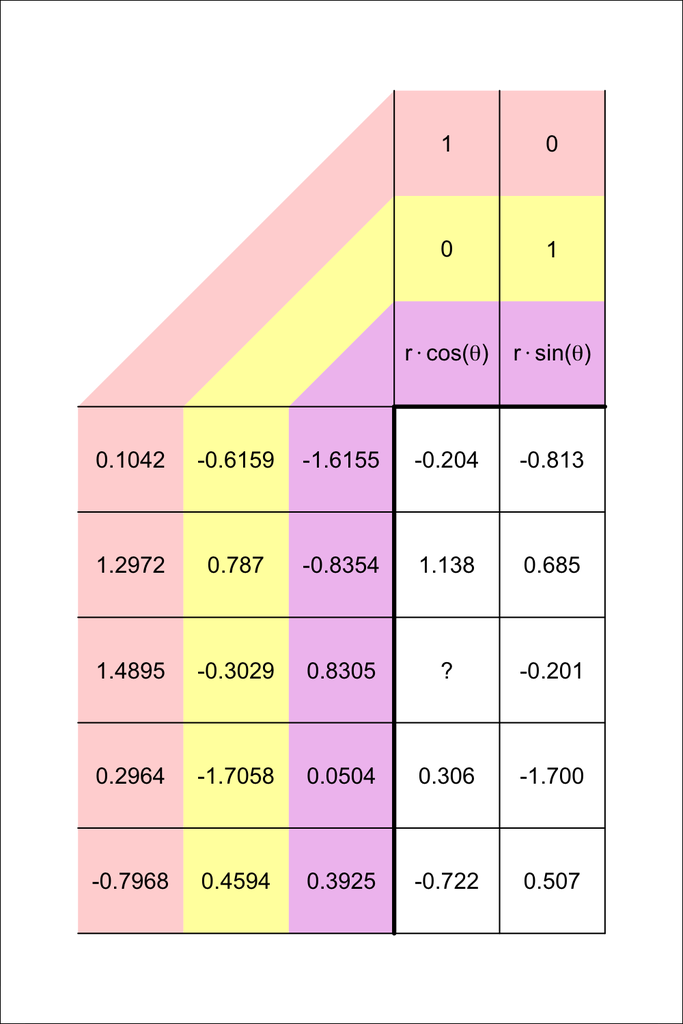

What is the new $x$ coordinate when point $(1.4895, -0.3029, 0.8305)$ is projected using the oblique projection with $\theta=0.5697$ and $r=0.2265$?

Find the projection matrix by pluggin in $\theta=0.5697$ and $r=0.2265$.

$$P=\begin{bmatrix}
1 & 0\\
0 & 1\\
0.19072723029034 & 0.12216944636764
\end{bmatrix}$$

We use row 3 of the points matrix and column 1 of the projection matrix.

$$(1.4895)(1)~+~(-0.3029)(0)~+~(0.8305)(0.1907272)$$

Thus, $x=1.647899$.

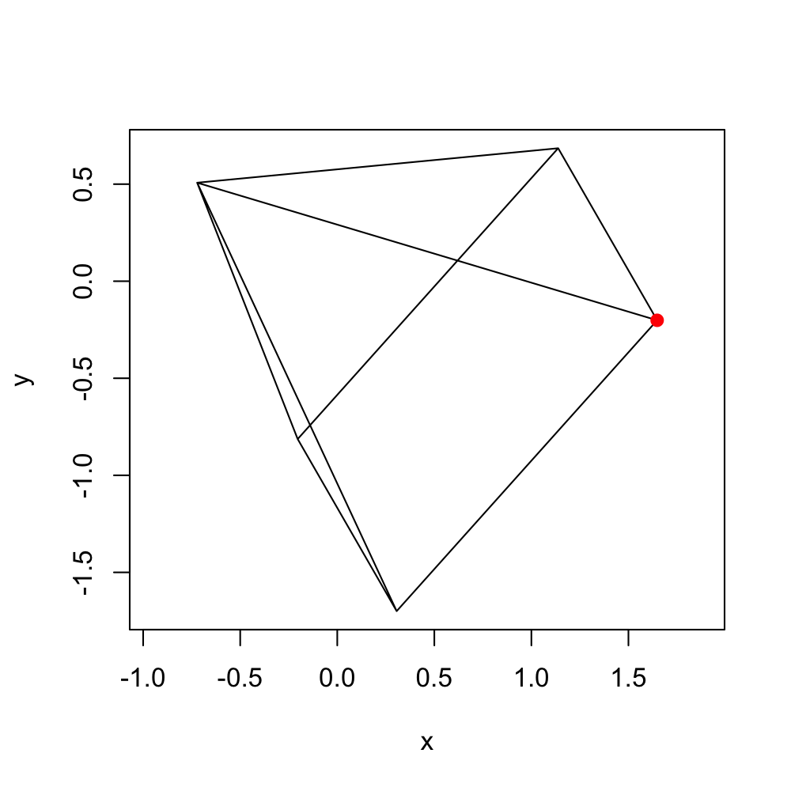

A video-game developer is hoping to apply an [oblique projection](https://en.wikipedia.org/wiki/Oblique_projection) to show a set of 3D points as a 2D image. The starting points are stored as rows in a 5 $\times$ 3 matrix $S$.

$$S=\begin{bmatrix}
-1.1441 & 1.2663 & -0.296\\
0.3399 & 0.7394 & -1.5289\\
-0.1166 & -1.1884 & -1.2547\\
-1.6006 & -0.6615 & -0.0218\\
0.6303 & -0.039 & 0.7753
\end{bmatrix}$$

The oblique projection matrix $P$ has two key parameters: $\theta$ and $r$. For this problem, use $\theta=0.6142$ and $r=0.5015$.

$$P~=~\begin{bmatrix}
1 & 0\\
0 & 1\\
r\cdot\cos(\theta) & r\cdot\sin(\theta)
\end{bmatrix}$$

The final points (in matrix $F$) are found by multiplying $S\cdot P$.

$$F=S\cdot P$$

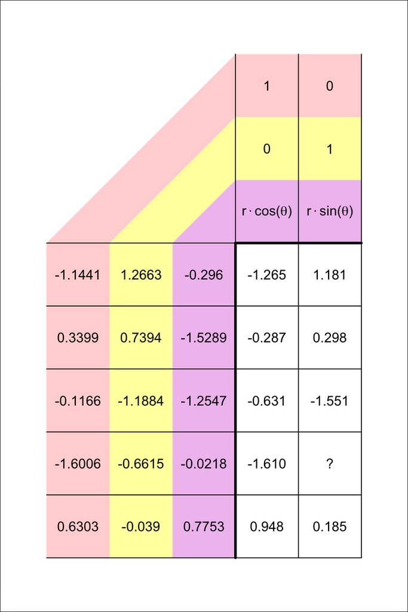

What is the new $y$ coordinate when point $(-1.6006, -0.6615, -0.0218)$ is projected using the oblique projection with $\theta=0.6142$ and $r=0.5015$?

Find the projection matrix by pluggin in $\theta=0.6142$ and $r=0.5015$.

$$P=\begin{bmatrix}
1 & 0\\
0 & 1\\
0.409843228279417 & 0.289016916863885
\end{bmatrix}$$

We use row 4 of the points matrix and column 2 of the projection matrix.

$$(-1.6006)(0)~+~(-0.6615)(1)~+~(-0.0218)(0.2890169)$$

Thus, $y=-0.6678006$.

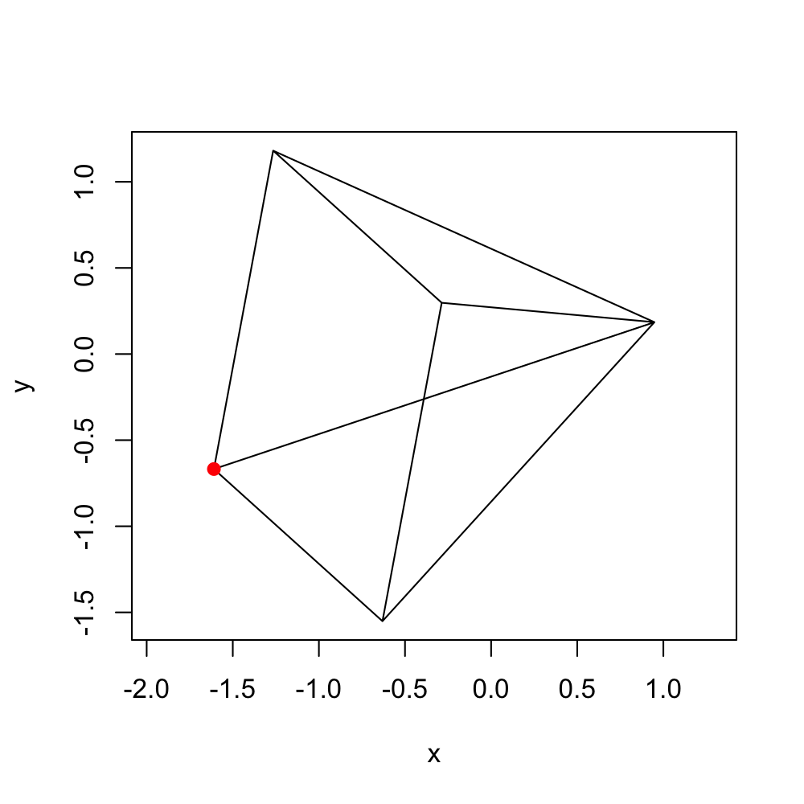

A video-game developer is hoping to apply an [oblique projection](https://en.wikipedia.org/wiki/Oblique_projection) to show a set of 3D points as a 2D image. The starting points are stored as rows in a 5 $\times$ 3 matrix $S$.

$$S=\begin{bmatrix}
-0.6177 & 0.9374 & 1.319\\
0.7485 & -0.5149 & 1.4746\\
1.7139 & 0.2229 & -0.114\\
0.3477 & 1.6752 & -0.2696\\
-0.5481 & -0.5801 & -0.6025
\end{bmatrix}$$

The oblique projection matrix $P$ has two key parameters: $\theta$ and $r$. For this problem, use $\theta=0.6258$ and $r=0.5477$.

$$P~=~\begin{bmatrix}
1 & 0\\
0 & 1\\
r\cdot\cos(\theta) & r\cdot\sin(\theta)
\end{bmatrix}$$

The final points (in matrix $F$) are found by multiplying $S\cdot P$.

$$F=S\cdot P$$

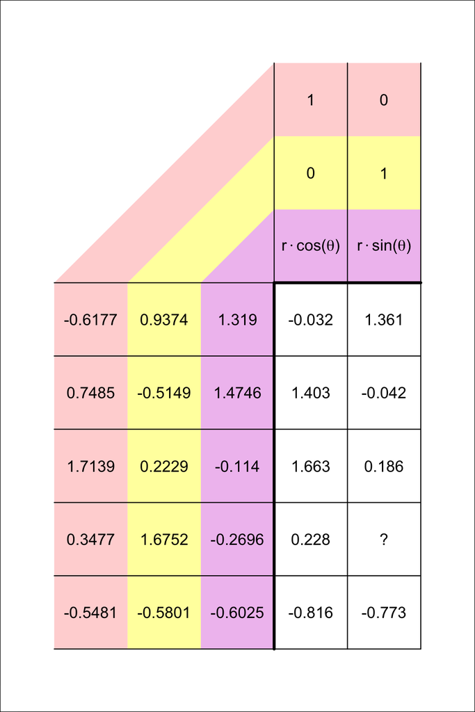

What is the new $y$ coordinate when point $(0.3477, 1.6752, -0.2696)$ is projected using the oblique projection with $\theta=0.6258$ and $r=0.5477$?

Find the projection matrix by pluggin in $\theta=0.6258$ and $r=0.5477$.

$$P=\begin{bmatrix}
1 & 0\\
0 & 1\\
0.443907992226609 & 0.320813005405549
\end{bmatrix}$$

We use row 4 of the points matrix and column 2 of the projection matrix.

$$(0.3477)(0)~+~(1.6752)(1)~+~(-0.2696)(0.320813)$$

Thus, $y=1.5887088$.

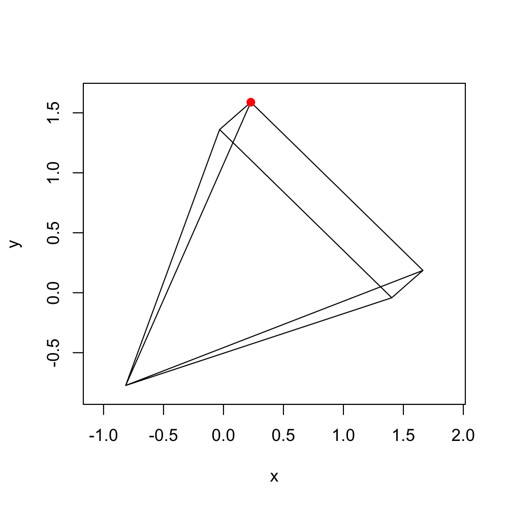

A video-game developer is hoping to apply an [oblique projection](https://en.wikipedia.org/wiki/Oblique_projection) to show a set of 3D points as a 2D image. The starting points are stored as rows in a 5 $\times$ 3 matrix $S$.

$$S=\begin{bmatrix}
-0.1579 & 0.7541 & 1.5513\\
-1.6452 & -0.1096 & 0.5305\\
-0.4586 & -1.666 & 0.1186\\
1.0287 & -0.8023 & 1.1393\\
0.3082 & 0.456 & -0.8349
\end{bmatrix}$$

The oblique projection matrix $P$ has two key parameters: $\theta$ and $r$. For this problem, use $\theta=0.8348$ and $r=0.2255$.

$$P~=~\begin{bmatrix}
1 & 0\\
0 & 1\\
r\cdot\cos(\theta) & r\cdot\sin(\theta)
\end{bmatrix}$$

The final points (in matrix $F$) are found by multiplying $S\cdot P$.

$$F=S\cdot P$$

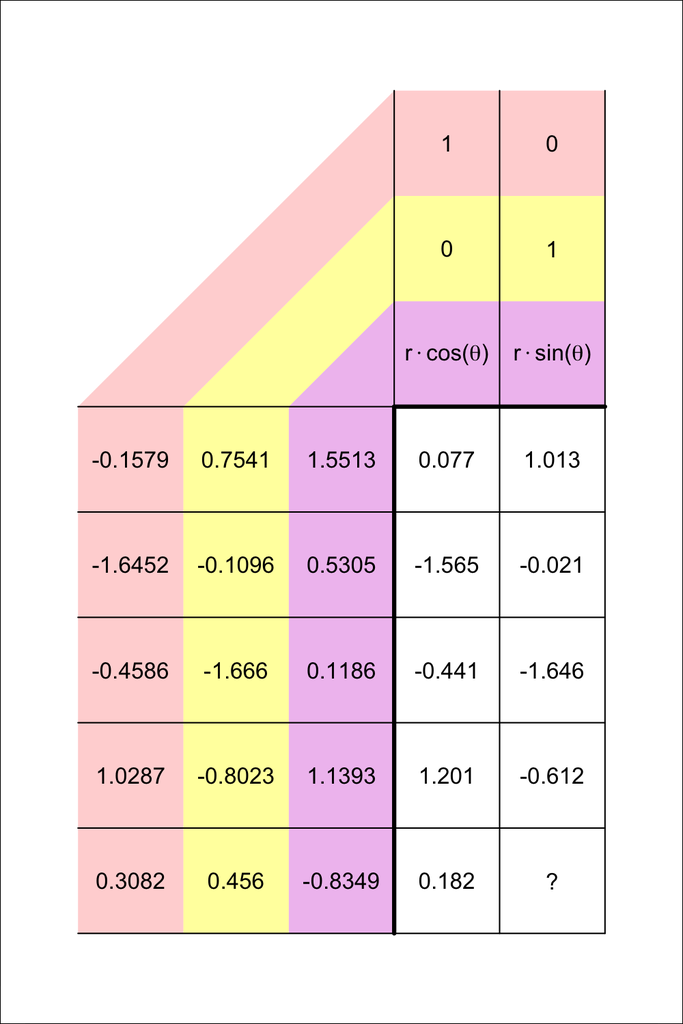

What is the new $y$ coordinate when point $(0.3082, 0.456, -0.8349)$ is projected using the oblique projection with $\theta=0.8348$ and $r=0.2255$?

Find the projection matrix by pluggin in $\theta=0.8348$ and $r=0.2255$.

$$P=\begin{bmatrix}
1 & 0\\
0 & 1\\
0.151383996885239 & 0.167132089938019
\end{bmatrix}$$

We use row 5 of the points matrix and column 2 of the projection matrix.

$$(0.3082)(0)~+~(0.456)(1)~+~(-0.8349)(0.1671321)$$

Thus, $y=0.3164614$.

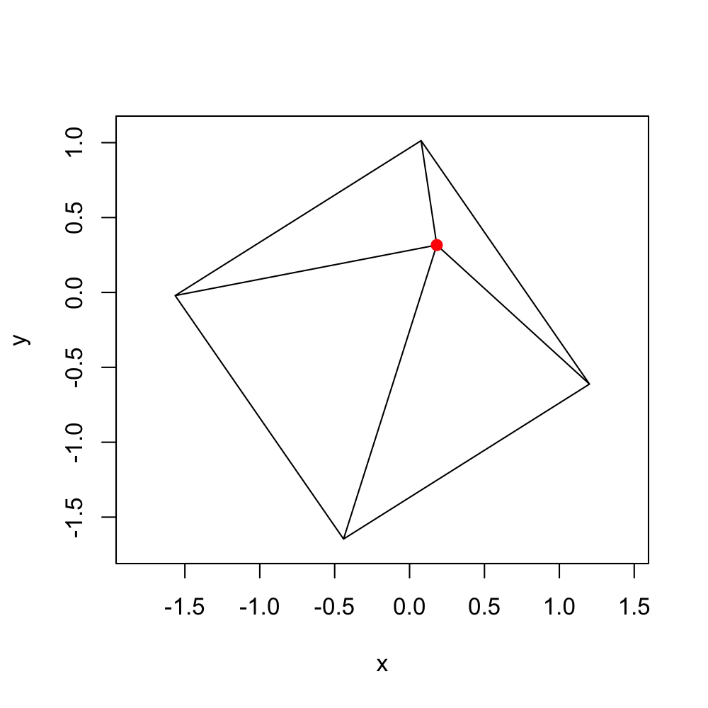